# High Performance Computing 2024 - Part 2

The requirements for this assignment are described [here](https://github.com/Foundations-of-HPC/High-Performance-Computing-2023/blob/main/ASSIGNMENTS/exercise2/exercise2.md).  
In this report, implementations for the exercises `2B` and `2C` are proposed.

## Section 1

The exercise `2B` requires to develop a parallel version of the `quicksort algorithm`, starting from a given, recursive, [serial implementation](https://github.com/Foundations-of-HPC/High-Performance-Computing-2023/blob/main/ASSIGNMENTS/exercise2/quicksort.c).  
At each recursive call, an auxiliary function, called `partitioning`, is called. This function selects one element of the array (referred to as `pivot`) and rearranges the array such that all the values smaller than the pivot are on its left side, all the values bigger than it are on its right side. Now, quicksort is called on both subarrays, and the process continues until the array size is such that it is not possible to partition it anymore (`size=2`).

In the parallel version of quicksort, the logic of the algorithm is maintained. The difference is that the data has to be subdivided between multiple processes, that independently perform the sorting.  
This introduces the needs to:  
• elaborate a strategy to distribute the data;  
• find a way to get the data back, while ensuring the data is correctly sorted (or the sorting is preserved?).

There are different ways the data can be distributed among the processes in the context of a parallel MPI program:  
(a) a single MPI process generates the data chunks and sends them to each other process;  
(b) each MPI process generates its own chunk of data;  
(c) the data is read from a file.  
Here, the first strategy is used: the root process (`rank=0`) generates and uniformly distributes the data to the other processes in the communicator.

#### Memory allocation

The first relevant detail of the implementation is the choice to allocate the memory needed to each process only once in the beginning. Two arrays are defined, `own_sizes` and `total_sizes`: each entry denotes, for a specific process, the size of the chunk which will be obtained with the initial distribution and the size of the owned chunk after all the merging steps involving the process (see below), respectively.  
Then, each process allocates two memory regions: `mydata`, for all the data got from the distribution and the merging, and `receive_buffer`, to accept data from other processes.  
By preallocating all the memory each process will need, it is possible to avoid repeated calls to `malloc` and `free`, minimizing potential memory fragmentation and possibly leading to reduced overhead and more predictable memory usage patterns:

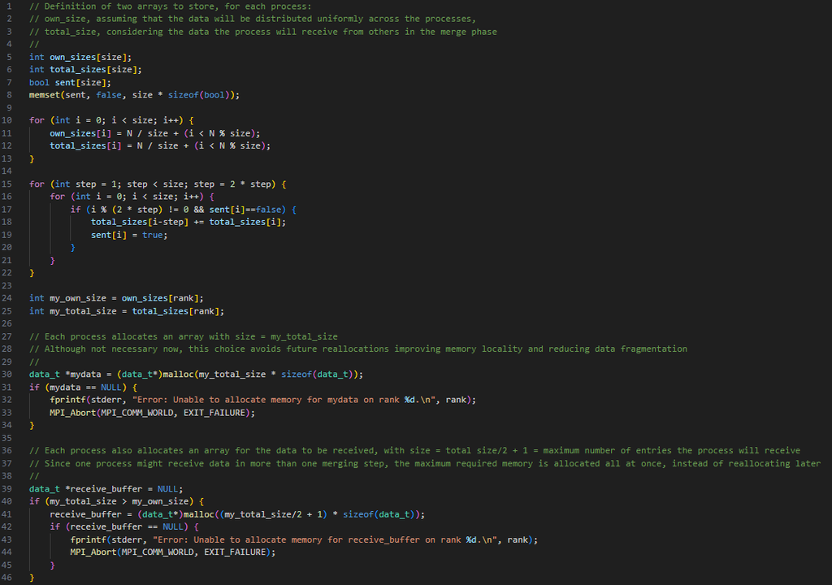

#### Distribution

Now, the root process tries to dynamically allocate memory for all the data. If the allocation is successful, the data is generated (simply iterating through the entries of the array and assigning to each entry a random value in `[0,1)`).  
Then, the root process gets ready to distribute the data through a `scatter` communication. However, since the array length might not be divisible for the number of processes, the root defines the `sendcounts` and the `displacements` for all the processes, i.e., the number of elements to be sent to each specific process and the index of the first of such elements. Each process will receive its chunk of data on a memory region allocated beforehand, with a size equal to the `sendcount` associated to the process itself by the root.  
The code used to implement the described procedure is the following:

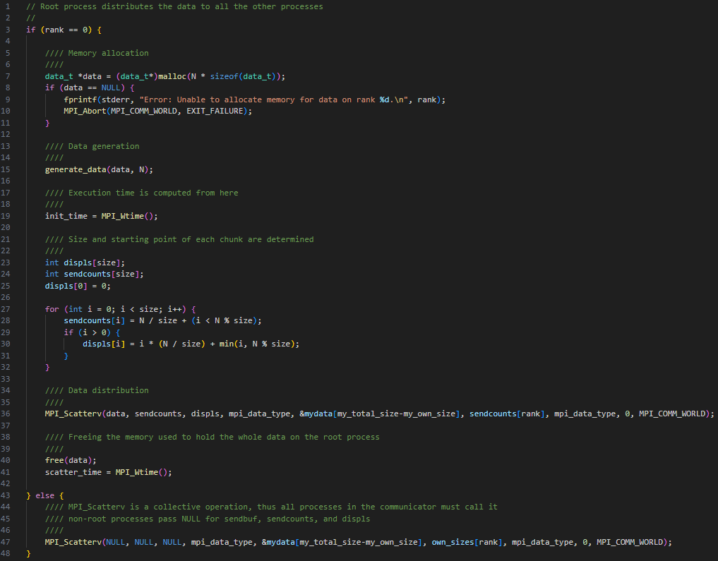

Data generation and distribution

Once the distribution is completed, the quicksort algorithm is executed independently by each of the processes on their respective data.

#### Merging

Once all the chunks are sorted, they need to be merged together to return the overall sorted array. One naive solution would be to collect all the chunks at the root process (using an efficient communication routine like `MPI_Gather`) and then perform one big merge here. However, this would be a waste of resources, since all the processes would remain idle while the root performs the merge.  
Here, an iterative binary tree-based merging with logarithmic steps is performed (using a standard Merge sort algorithm):

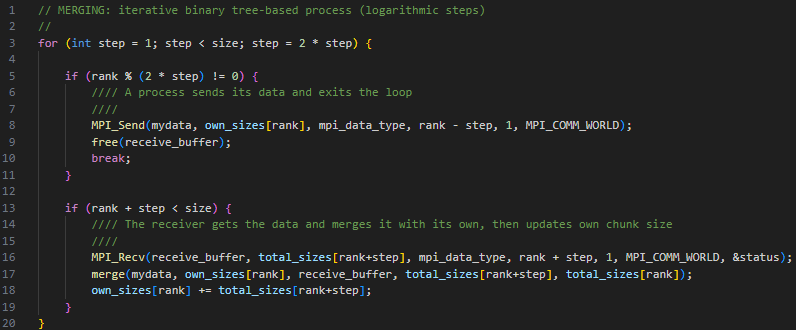

Basically, at a certain step, half of the processes send their data and exit the loop, and the other half receive the data and merge it with their own data, doubling their own chunk size. Given $P$ processes, the merge requires $\log_2 P$ steps.

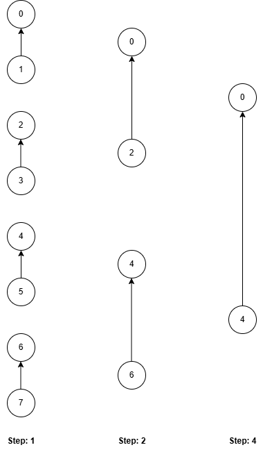

Binary-tree based merging for `N=8` processes.

#### Other implementation details

Some other details of the implementation deserve to be reported.

• The `partitioning` function has been slightly modified to allow the selection of a different pivot. In the original code, the pivot was selected to be the last element of the array, which can lead to poor performance if the data is already sorted or nearly sorted. The `median_of_three` function has been introduced, which determines the median of three given values. The new strategy is to choose the median of the first, middle, and last elements as the pivot, according to the idea that this value is more likely to be closer to the median of the entire array, improving the chances that the partitions will be more balanced.  
By swapping the selected median with the last element, the code ensures that the pivot is used correctly in the partitioning logic.

• For the time measurements, the function `MPI_Wtime` is employed.  
The execution time is measured from the termination of the data generation phase (`init_time`), since the time required by that operation is irrelevant for the study of the scalability of the parallel quicksort algorithm.  
The time is also measured after the completion of the scatter operation (`scatter_time`), after all the processes terminate the quicksort (`sorting_time`), and finally after the merge (`end_time`).  
Therefore, the total execution time is then composed as follows:  
- Distribution: `scatter_time` - `init_time`  
- Sorting: `sorting_time`-`scatter_time`  
- Merging: `end_time`-`sorting_time`

• Some checks are introduced after every dynamic memory allocation (`malloc`) in the code.

• A function has been introduced with the goal of monitoring the memory consumption during the execution: `get_meminfo`. This function is able to retrieve, inside of a C program, the memory information that is usually accessible from the Linux terminal with the `free` command: the current values of total, used, free, shared, buff/cache and available memory on the machine.

#### Required memory estimation

Based on the amount of allocated memory for each core, one might evaluate an upper bound on the memory requirements of the program execution.  
Let’s consider the case where the array has dimension $N = P$, so that each CPU should receive 1 data unit of size $x$ bytes. The memory requirements for some $P$ values are reported below:

P=4

|  | mydata | receive_buffer |
| --- | --- | --- |
| 0 | 4 | 2 |
| 1 | 1 | 0 |
| 2 | 2 | 1 |
| 3 | 1 | 0 |
| **Total** | **8*x** | **3*x** |

P=8

|  | mydata | receive_buffer |
| --- | --- | --- |
| 0 | 8 | 4 |
| 1 | 1 | 0 |
| 2 | 2 | 1 |
| 3 | 1 | 0 |
| 4 | 4 | 2 |
| 5 | 1 | 0 |
| 6 | 2 | 1 |
| 7 | 1 | 0 |
| **Total** | **20*x** | **8*x** |

P=16

|  | mydata | receive_buffer |
| --- | --- | --- |
| 0 | 16 | 8 |
| 1 | 1 | 0 |
| 2 | 2 | 1 |
| 3 | 1 | 0 |
| 4 | 4 | 2 |
| 5 | 1 | 0 |
| 6 | 2 | 1 |
| 7 | 1 | 0 |
| 8 | 8 | 4 |
| 9 | 1 | 0 |
| 10 | 2 | 1 |
| 11 | 1 | 0 |
| 12 | 4 | 2 |
| 13 | 1 | 0 |
| 14 | 2 | 1 |
| 15 | 1 | 0 |
| **Total** | **48*x** | **20*x** |

In practice, it works just fine to choose a problem size $N$ such that the memory required to allocate $3 \times N$ is within 70-80% of the free memory of the machine.  
In fact, one needs space to allocate $N$ entries during the data generation and $N$ during the data distribution. Then, at merging time, each process sending data will free all its allocated memory immediatelyafter, bringing to a temporary increase in the utilized memory of at most the sender’s `mydata`. Since in any merging step half of the processes send and the other half receive, one should consider an overall additional memory for $N/2$ data entries.

#### Results

In this section, the results are presented for the tests on the MPI parallel quicksort algorithm on a `EPYC` node.

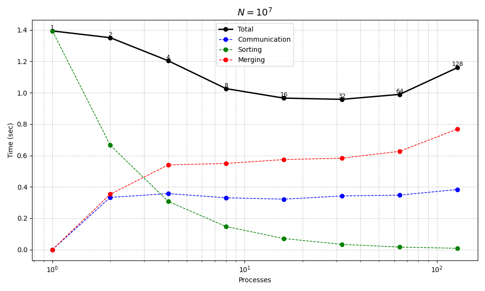

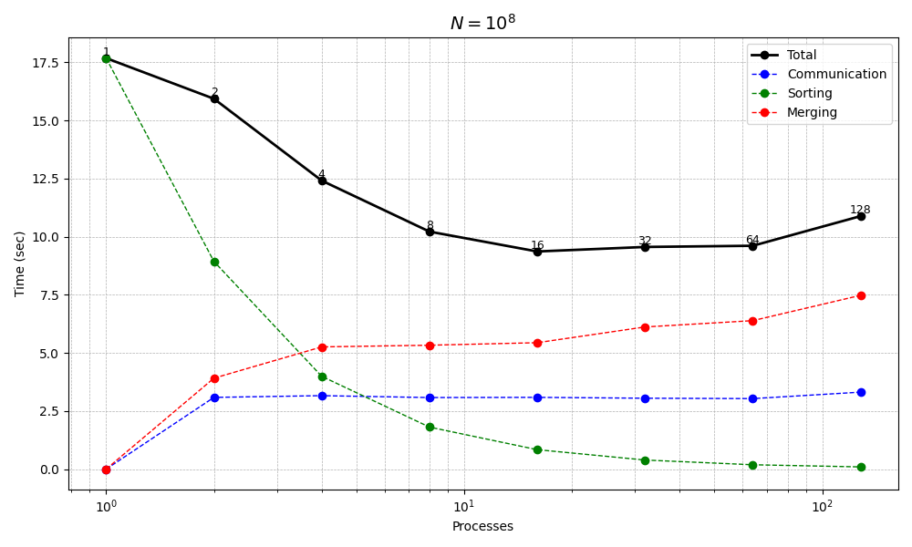

[figure not shown]

Strong scalability tests

As expected, the sorting time for a problem of fixed size decreases linearly with the number of involved processes. On the other hand, the merging time progressively increases, quickly becoming the main contributor of the total time.  
Overall, the execution time decreases up to intermediate values for the number of processes, with a final increase when all the available CPUs are employed.

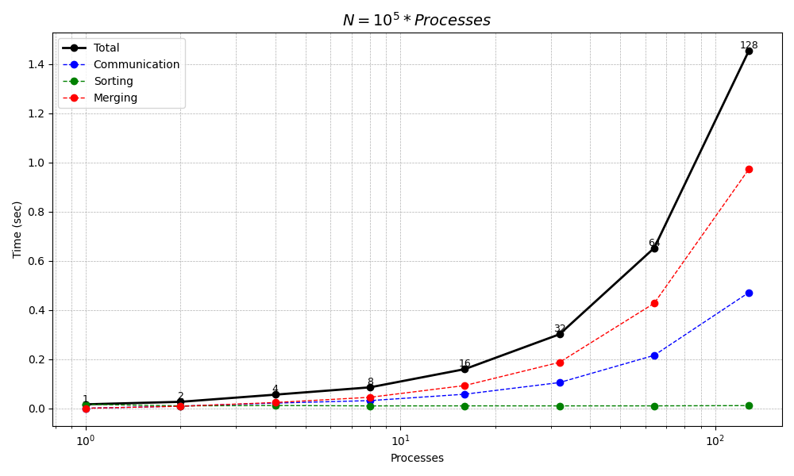

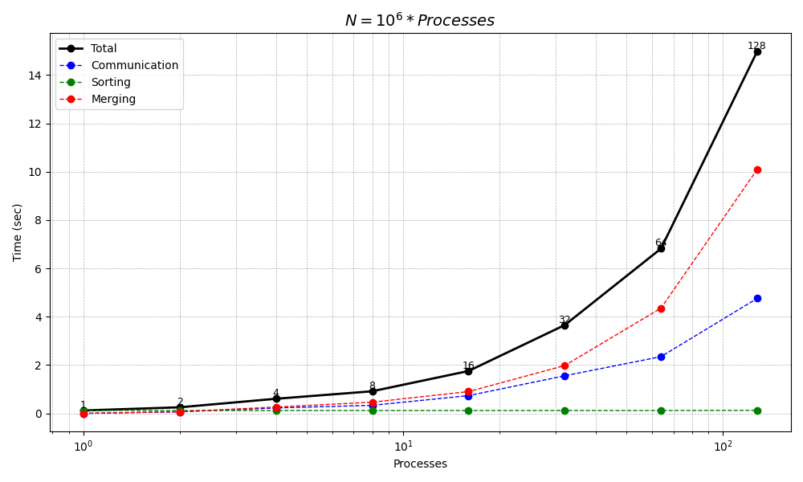

Weak scalability tests

When the problem size is adapted to the number of CPUs, the sorting time is constant, but since the merging time keeps increasing, the total time does as well.

## Section 2

The exercise `2C` is an implementation of a parallel algorithm to determine the Mandelbrot set. Here, an OpenMP version is presented.  
The [Mandelbrot set](https://en.wikipedia.org/wiki/Mandelbrot_set) is defined in the complex plane as the complex numbers `c` for which the function $f_c(z)=z^2+c$ does not diverge to infinity when iterated starting at `z=0`, i.e., for which the sequence $f_c(0),f_c(f_c(0))$, etc., remains bounded in absolute value.

In practice, one chooses the maximum number of iterations for the update of the function $f_c(z)$. If the function value does not exceed a certain value (`2`) within the last iteration, the complex number `c` is considered to belong to the Mandelbrot set. Thus, the accuracy of the retrieved set depends on the chosen limit of iterations.

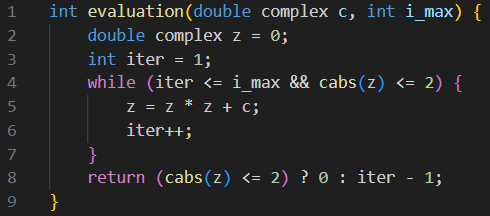

For the implementation of the algorithm, a portion of the complex plane is considered, and it is uniformly subdivided to obtain a series of complex numbers.  
Each of these numbers is evaluated to belong to the Mandelbrot set or not, and assigned `0` or the value of the iteration where it exceeded the threshold `2`, respectively. Finally, these values are plotted to the pixels of a `PGM` image to be visualized.

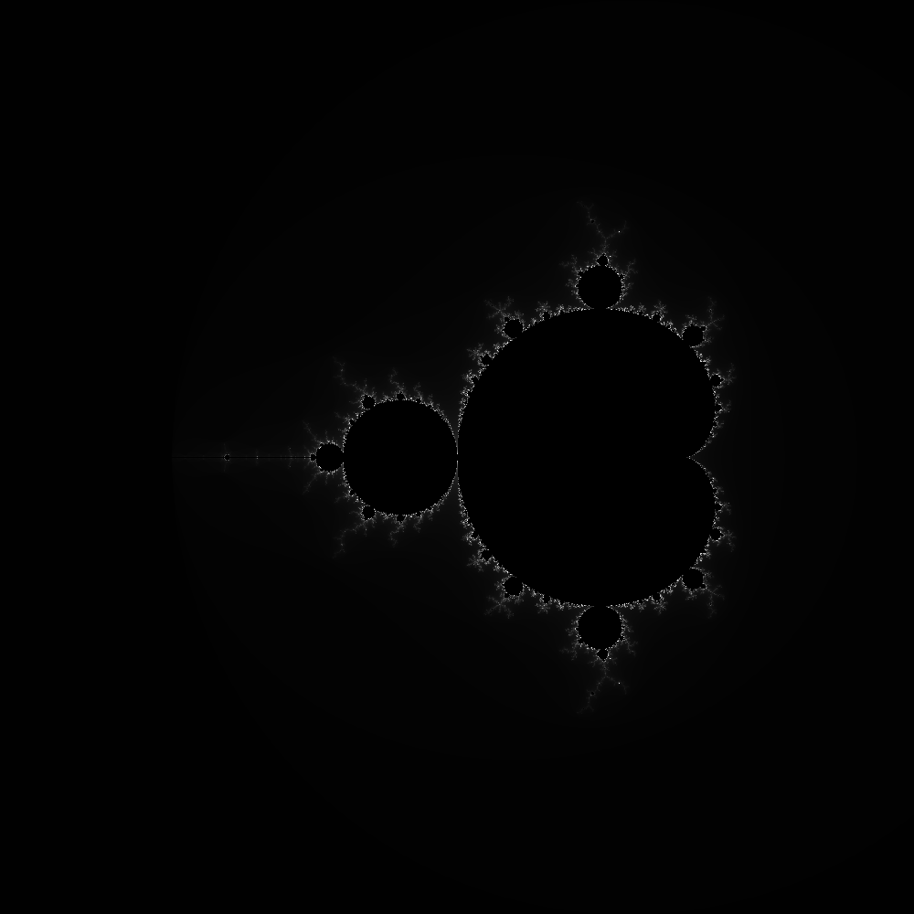

255 iterations

[figure not shown]

65535 iterations

Mandelbrot set.

Some results are presented below, running the OpenMP parallel program on my machine:

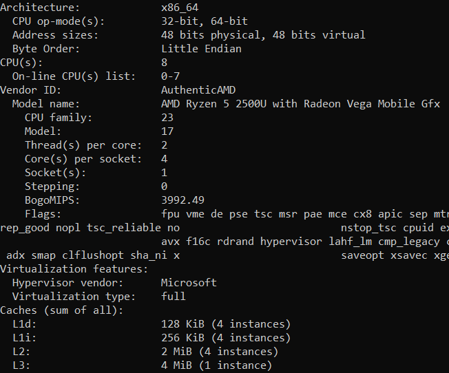

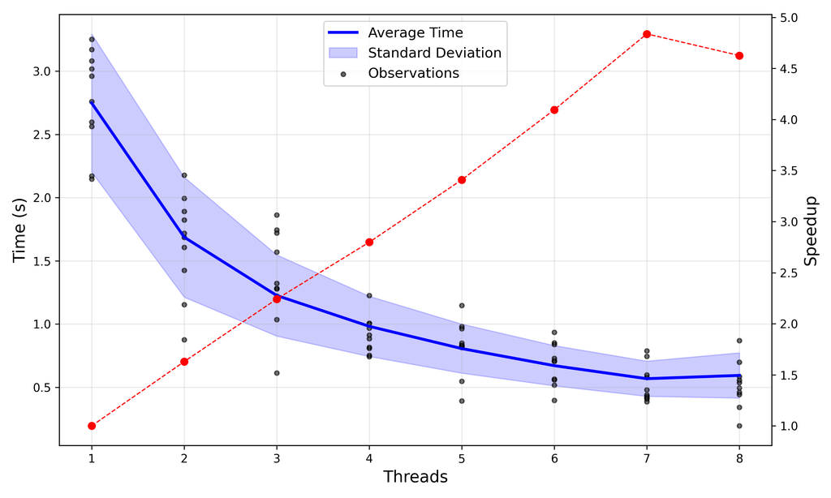

Strong

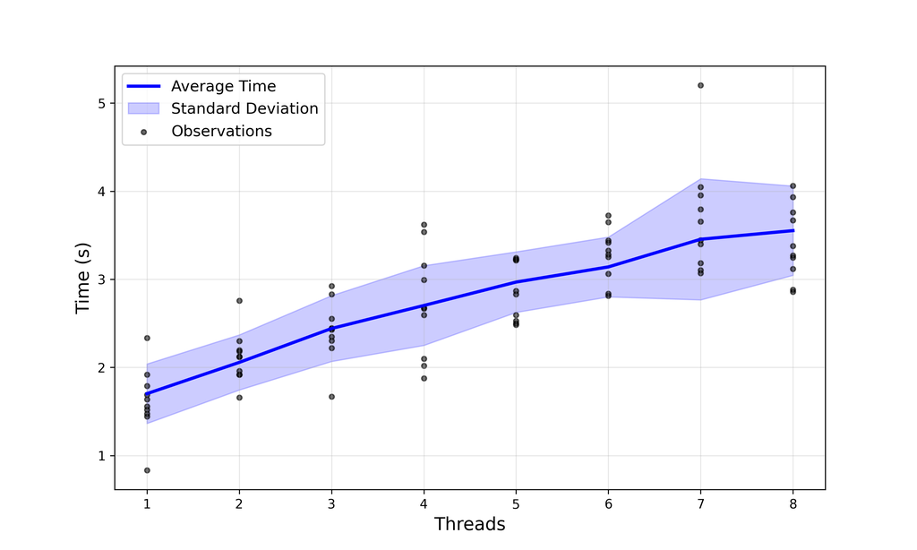

Weak

Scalability tests for program executions with `255` iterations and `2000x2000` points.